# Model_Training

### 0. Clean Up

```python
import shutil
shutil.rmtree("folder")
```

### 1. Montarea Google Drive și extragerea arhivei `.zip` în workspace-ul Colab

- Montăm Google Drive
- Copiem arhiva `dataset.zip` în workspace-ul local Colab (`/content`)
- Dezarhivăm fișierele

```python
from google.colab import drive
drive.mount('/content/drive')
```

```python
!cp "/content/drive/MyDrive/Colab Notebooks/PS_Proiect/dataset.zip" /content/
```

```python
import zipfile

with zipfile.ZipFile("dataset.zip", 'r') as zip_ref:
    zip_ref.extractall("dataset")

print("Fisierele au fost extrase in: /content/dataset")
```

```
Fisierele au fost extrase in: /content/dataset
```

### 2. Încărcarea și organizarea setului de date

- Parcurgem toate fișierele `.wav` și extragem calea completă
- Identificăm emoția din numele folderului părinte (ex: OAF_happy -> happy)
- Construim un **DataFrame** (structură tabelară pentru analiză și manipulare) cu două coloane: **audio_path** și **label**
- Afișăm primele înregistrări și distribuția etichetelor

```python
import os
import pandas as pd

# definim calea catre directorul cu fisierele extrase
base_path = '/content/dataset/input'

# initializam listele
audio_paths = []
labels = []

# parcurgem toate fisierele din director
for root, _, files in os.walk(base_path):
    for file in files:
        if file.endswith('.wav'):
            file_path = os.path.join(root, file)
            audio_paths.append(file_path)

            # extragem emotia din numele folderului
            folder_name = os.path.basename(root)
            emotion = folder_name.split('_')[-1].lower()
            labels.append(emotion)

# afisam informatiile despre dataset
print(f"Dataset incarcat cu succes!")
print(f"Total fisiere audio: {len(audio_paths)}")

# cream un DataFrame din listele obtinute
df = pd.DataFrame({
    'audio_path': audio_paths,
    'label': labels
})

# afisam primele randuri din dataset
n = 10
print(f"\nPrimele {n} inregistrari:")
print(df.head(n))

# afisam distributia emotiilor
print("\nDistributia etichetelor:")
print(df['label'].value_counts())
```

```
Dataset incarcat cu succes!
Total fisiere audio: 2800

Primele 10 inregistrari:
                                          audio_path label
0  /content/dataset/input/YAF_fear/YAF_chief_fear...  fear
1  /content/dataset/input/YAF_fear/YAF_tire_fear.wav  fear
2  /content/dataset/input/YAF_fear/YAF_white_fear...  fear
3  /content/dataset/input/YAF_fear/YAF_shirt_fear...  fear
4  /content/dataset/input/YAF_fear/YAF_pole_fear.wav  fear
5   /content/dataset/input/YAF_fear/YAF_gap_fear.wav  fear
6   /content/dataset/input/YAF_fear/YAF_nag_fear.wav  fear
7  /content/dataset/input/YAF_fear/YAF_juice_fear...  fear
8  /content/dataset/input/YAF_fear/YAF_pool_fear.wav  fear
9  /content/dataset/input/YAF_fear/YAF_five_fear.wav  fear

Distributia etichetelor:
label
fear         400
neutral      400
disgust      400
sad          400
angry        400
surprised    400
happy        400
Name: count, dtype: int64
```

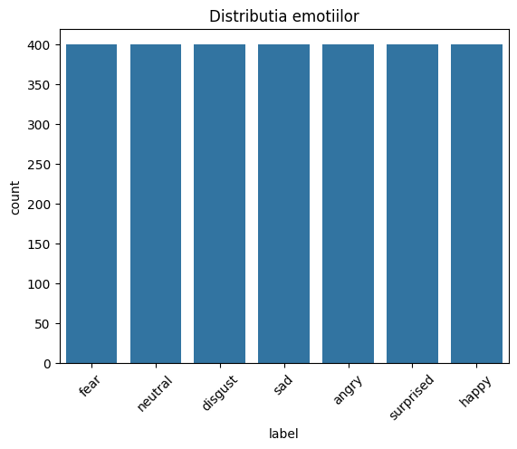

```python
import seaborn as sns
import matplotlib.pyplot as plt

sns.countplot(data=df, x='label')
plt.xticks(rotation=45)
plt.title("Distributia emotiilor")
plt.show()
```

### 3. Analiza exploratorie a semnalelor audio (Waveform + Spectrogramă)

- **Waveform** (forma de undă): reprezintă variația amplitudinii semnalului în timp. Ne ajută să observăm intensitatea și dinamica vocii
- **Spectrograma**: oferă o reprezentare în frecvență-timp a semnalului. Utilă pentru înțelegerea tonalității și a intonației vocale

```python
import librosa
import librosa.display
import matplotlib.pyplot as plt
import numpy as np
from IPython.display import Audio

# afisare waveform si spectrograma
def plot_wave_and_spec(data, sr, emotion):
    fig, axs = plt.subplots(2, 1, figsize=(7, 5))

    # waveform
    axs[0].set_title(f"Waveform - {emotion}", size=16)
    librosa.display.waveshow(data, sr=sr, ax=axs[0])
    axs[0].set_xlabel("Timp (secunde)")
    axs[0].set_ylabel("Amplitudine")

    # spectrograma
    x = librosa.stft(data)
    xdb = librosa.amplitude_to_db(abs(x))
    img = librosa.display.specshow(xdb, sr=sr, x_axis='time', y_axis='hz', ax=axs[1])
    axs[1].set_title(f"Spectrograma - {emotion}", size=16)

    # colorbar spectograma
    fig.colorbar(img, ax=axs[1], format="%+2.0f dB")

    plt.tight_layout()
    plt.show()
```

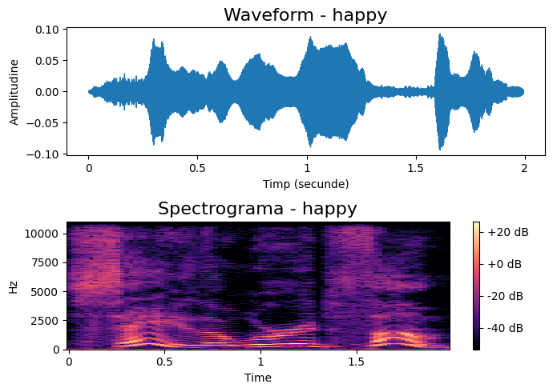

[interactive chart not shown]

```python
emotion = 'happy'  # alegem emotia pe care sa o afisam
path = df[df['label'] == emotion]['audio_path'].values[10]
data, sampling_rate = librosa.load(path)  # incarcam fisierul audio
plot_wave_and_spec(data, sampling_rate, emotion)  # afisam waveform si spectrograma
Audio(path)  # player audio
```

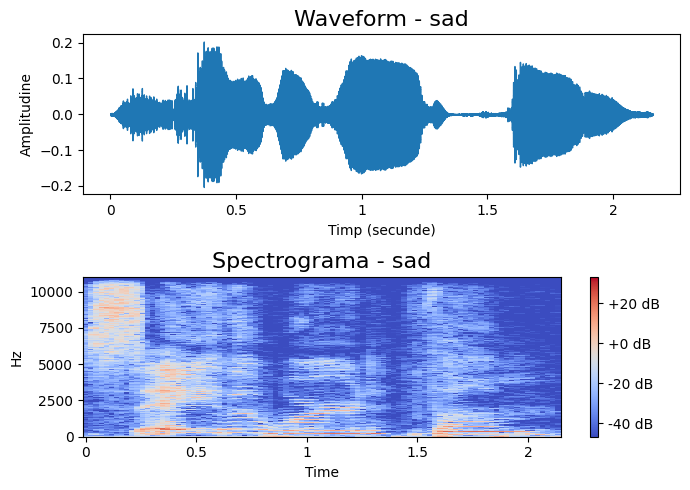

[interactive chart not shown]

```python
emotion = 'sad'  # alegem emotia pe care sa o afisam
path = df[df['label'] == emotion]['audio_path'].values[9]
data, sampling_rate = librosa.load(path)  # incarcam fisierul audio
plot_wave_and_spec(data, sampling_rate, emotion)  # afisam waveform si spectrograma
Audio(path)  # player audio
```

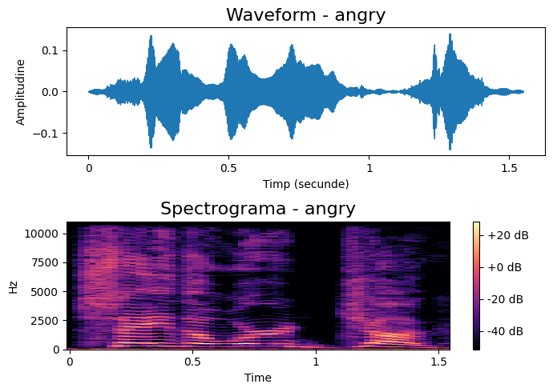

[interactive chart not shown]

```python
emotion = 'angry'  # alegem emotia pe care sa o afisam
path = df[df['label'] == emotion]['audio_path'].values[5]
data, sampling_rate = librosa.load(path)  # incarcam fisierul audio
plot_wave_and_spec(data, sampling_rate, emotion)  # afisam waveform si spectrograma
Audio(path)  # player audio
```

### 4. Crearea clasei personalizate **SpeechEmotionDataset**

- Convertim etichetele din text (ex: "happy") în valori numerice (0, 1, etc.), necesare pentru clasificare
- Definim o clasă personalizată **SpeechEmotionDataset** care: -- moștenește `torch.utils.data.Dataset` pentru un dataset compatibil cu PyTorch și HuggingFace -- încarcă fișierul audio în **DataFrame** -- îl păstrează sau ajustează la o lungime fixă -- îl procesează cu `Wav2Vec2Processor` pentru a obține `input_values` compatibile cu modelul (normalizare, padding, conversie în tensori)

```python
from torch.utils.data import Dataset
import torch
import torchaudio
import numpy as np

# conversie etichete string -> int
unique_labels = sorted(df['label'].unique())  # obtinem etichetele sortate
label_map = {label: idx for idx, label in enumerate(unique_labels)}
# conversie etichete int -> string
inverse_label_map = {idx: label for label, idx in label_map.items()}
df['label'] = df['label'].map(label_map)

# clasa personalizata pentru dataset
class SpeechEmotionDataset(Dataset):
    def __init__(self, df, processor, max_length=16000):
        self.df = df
        self.processor = processor
        self.max_length = max_length

    def __len__(self):
        return len(self.df)

    def __getitem__(self, idx):
        audio_path = self.df.iloc[idx]['audio_path']
        label = self.df.iloc[idx]['label']

        # incarcam fisierul audio
        speech, sr = librosa.load(audio_path, sr=16000)

        # ajustam lungimea audio (padding sau truncare)
        if len(speech) > self.max_length:
            speech = speech[:self.max_length]
        else:
            speech = np.pad(speech, (0, self.max_length - len(speech)), mode='constant')

        # preprocesare cu Hugging Face processor (Wav2Vec2)
        inputs = self.processor(speech, sampling_rate=sr, return_tensors='pt', padding=True, truncation=True, max_length=self.max_length)

        # eliminam dimensiunea 1 de pe axa 0 (batch)
        input_values = inputs.input_values.squeeze(0)
        return {
            'input_values': input_values,
            'labels': torch.tensor(label, dtype=torch.long)
        }
```

### 5: Împărțirea datelor și inițializarea modelului **Wav2Vec2**

- Împărțim setul de date în două subseturi: 80% pentru antrenare, 20% pentru testare
- Inițializăm `Wav2Vec2Processor` pentru conversia semnalului audio brut într-un format numeric (tensor)
- Încărcăm modelul pre-antrenat `Wav2Vec2ForSequenceClassification` și specificăm numărul de clase (emoții)

```python
from sklearn.model_selection import train_test_split
from transformers import Wav2Vec2Processor, Wav2Vec2ForSequenceClassification

# impartirea datelor in set de antrenare si test
# proportia de date pentru setul test; random_state asigura impartirea constanta
train_df, test_df = train_test_split(df, test_size=0.2, random_state=42)

# initializarea procesorului Wav2Vec2
processor = Wav2Vec2Processor.from_pretrained("facebook/wav2vec2-base")

# initializarea modelului de clasificare
model = Wav2Vec2ForSequenceClassification.from_pretrained(
    "facebook/wav2vec2-base",
    num_labels=len(label_map)
)
```

### 6: Pregătirea pentru antrenare și inițializarea **Trainer**

- Creăm obiectele `SpeechEmotionDataset` pentru seturile de antrenare și testare
- Setăm parametrii de antrenare folosind `TrainingArguments`
- Definim funcția `compute_metrics()` care va evalua performanța modelului
- Inițializăm HuggingFace `Trainer`, care va gestiona automat întregul proces de antrenare și evaluare
- Apelăm `trainer.train()` pentru a începe antrenarea efectivă a modelului **Wav2Vec2** pe datele noastre

```python
from torch.utils.data import DataLoader
from transformers import TrainingArguments, Trainer
from sklearn.metrics import accuracy_score, precision_recall_fscore_support
import numpy as np

# incarcam datasetul personalizat
train_dataset = SpeechEmotionDataset(train_df, processor)
test_dataset = SpeechEmotionDataset(test_df, processor)

# setam argumentele de antrenare
training_args = TrainingArguments(
    output_dir='./results',
    eval_strategy='epoch',
    save_strategy='epoch',
    learning_rate=2e-5,
    per_device_train_batch_size=16,
    per_device_eval_batch_size=16,
    num_train_epochs=3,
    weight_decay=0.01,
    report_to=[]  # evita logging la wandb sau tensorboard
)

# functie pentru metrici de evaluare
def compute_metrics(pred):
    labels = pred.label_ids
    preds = np.argmax(pred.predictions, axis=1)
    accuracy = accuracy_score(labels, preds)
    precision, recall, f1, _ = precision_recall_fscore_support(labels, preds, average='weighted')
    return {
        "accuracy": accuracy,
        "precision": precision,
        "recall": recall,
        "f1": f1
    }

# initializam HuggingFace Trainer
trainer = Trainer(
    model=model,
    args=training_args,
    train_dataset=train_dataset,
    eval_dataset=test_dataset,
    compute_metrics=compute_metrics
)

# start
trainer.train()
```

[420/420 2:51:45, Epoch 3/3]

| Epoch | Training Loss | Validation Loss | Accuracy | Precision | Recall | F1 |
| --- | --- | --- | --- | --- | --- | --- |
| 1 | No log | 0.783190 | 0.873214 | 0.899119 | 0.873214 | 0.858217 |
| 2 | No log | 0.357282 | 0.982143 | 0.983984 | 0.982143 | 0.982048 |
| 3 | No log | 0.262687 | 0.996429 | 0.996509 | 0.996429 | 0.996427 |

```
TrainOutput(global_step=420, training_loss=0.7648180280412946, metrics={'train_runtime': 10331.2851, 'train_samples_per_second': 0.65, 'train_steps_per_second': 0.041, 'total_flos': 6.100924032e+16, 'train_loss': 0.7648180280412946, 'epoch': 3.0})
```

```
Metrică	          Interpretare
----------------------------------------------------------------------
Training Loss	    Cât de bine învață modelul pe datele de antrenare
Validation Loss	  Cât de bine generalizează pe date nevăzute
Accuracy	         Câte predicții sunt corecte din total
Precision	        Cât de precise sunt predicțiile pozitive
Recall	           Câte exemple reale au fost corect recunoscute
F1	               Media armonică dintre Precision și Recall
```

### 7: Evaluarea performanței și testarea predicțiilor

- Evaluăm performanța modelului pe setul de test folosind funcția `trainer.evaluate()`, care returnează scoruri globale

```python
results = trainer.evaluate()
print(results)
```

[35/35 02:43]

```
{'eval_loss': 0.26268720626831055, 'eval_accuracy': 0.9964285714285714, 'eval_precision': 0.9965088282504013, 'eval_recall': 0.9964285714285714, 'eval_f1': 0.9964268177809844, 'eval_runtime': 168.5405, 'eval_samples_per_second': 3.323, 'eval_steps_per_second': 0.208, 'epoch': 3.0}
```

- Testăm modelul pe un exemplu audio ales aleatoriu din setul de test, comparând eticheta reală a emoției cu eticheta prezisă de model

```python
import random

idx = random.randrange(0, len(test_dataset))  # alegem un exemplu aleator
print("Original Label:", inverse_label_map[int(test_dataset[idx]['labels'])])
```

```
Original Label: disgust
```

```python
input_values = test_dataset[idx]['input_values'].unsqueeze(0).to('cpu')

with torch.no_grad():
    outputs = model(input_values)

logits = outputs.logits
predicted_class = logits.argmax(dim=-1).item()
print('Predicted Label:', inverse_label_map[predicted_class])
```

```
Predicted Label: disgust
```

### 8: Salvarea modelului antrenat în Google Drive

- Salvăm modelul `Wav2Vec2` și procesorul aferent folosind metodele specifice pentru Hugging Face

```python
# cream un folder in workspace (local)
model_save_path = "/content/emotion_recognition_model"

# mapare in config.json
inverse_label_map = {idx: label for label, idx in label_map.items()}
model.config.id2label = inverse_label_map
model.config.label2id = label_map

# salvam modelul si procesorul Hugging Face
model.save_pretrained(model_save_path)
processor.save_pretrained(model_save_path)
print("Modelul si procesorul au fost salvati local.")

# cream un folder in Google Drive
drive_path = "/content/drive/MyDrive/Colab Notebooks/PS_Proiect/emotion_recognition_model"
# copiem modelul din workspace in Drive
!cp -r {model_save_path} "{drive_path}"
print("Modelul a fost copiat in Google Drive:", drive_path)
```

```
Modelul si procesorul au fost salvati local.
Modelul a fost copiat in Google Drive: /content/drive/MyDrive/Colab Notebooks/PS_Proiect/emotion_recognition_model
```

Încărcarea modelului antrenat:

```
from transformers import Wav2Vec2Processor, Wav2Vec2ForSequenceClassification

# path model salvat
MODEL_DIR = "/content/drive/My Drive/Colab Notebooks/PS_Proiect/emotion_recognition_model"

# incarcam procesorul si modelul
processor = Wav2Vec2Processor.from_pretrained(MODEL_DIR)
model = Wav2Vec2ForSequenceClassification.from_pretrained(MODEL_DIR)
model.eval()

device = torch.device("cuda" if torch.cuda.is_available() else "cpu")
model = model.to(device)

print("Modelul a fost incarcat cu succes!")
```

### 9: Export în format `html`

```python
from google.colab import files, drive
drive.mount('/content/drive')
```

```python
%%shell
jupyter nbconvert --to html '/content/drive/MyDrive/Colab Notebooks/Licenta/PS_Proiect/Model_Training.ipynb' --output='/content/drive/MyDrive/Colab Notebooks/Licenta/PS_Proiect/Model_Training.html'
```

```python
files.download('/content/drive/MyDrive/Colab Notebooks/Licenta/PS_Proiect/Model_Training.html')
```